# 🧬 Analyse des Séquences ADN Synthétiques — Pipeline Data Science Complet

## 3. Préparation des données

> ⚠️ **Anti-leakage BO2** : `Num_A`, `Num_T`, `AT_Content` sont des **prédicteurs parfaits** de `GC_Content` (`GC = 100 − AT`). Les inclure dans la régression donnerait R²=1.0 trivial — sans aucune valeur. Seuls les **motifs de séquence** (`CpG_freq`, `kmer_3_freq`, etc.) sont utilisés pour BO2.

```python
# ── BO1 : CLASSIFICATION ──────────────────────────────────────────────
FEATURES_CLF = ['GC_Content','AT_Content','Num_A','Num_T','Num_C','Num_G',
                'kmer_3_freq','CpG_freq','purine_ratio','GC_skew','AT_skew','Mutation_Flag']

# ── BO2 : RÉGRESSION (aucune feature dérivée directement de GC_Content) ───────
FEATURES_REG = ['CpG_freq','kmer_3_freq','GC_skew','AT_skew','purine_ratio','Mutation_Flag']

print('═'*65)
print('BO1 — CLASSIFICATION')
print(f'  Cible    : Class_Label (Bacteria / Human / Virus / Plant)')
print(f'  Features : {len(FEATURES_CLF)} variables numériques')
print()
print('BO2 — RÉGRESSION')
print(f'  Cible    : GC_Content (nb de bases G+C, valeur continue 20-85)')
print(f'  Features : {FEATURES_REG}')
print(f'  ⚠️  Exclus pour éviter la tautologie : Num_C, Num_G, AT_Content, Num_A, Num_T')
print('═'*65)

# Encodage classification
le = LabelEncoder()
y_clf = le.fit_transform(df['Class_Label'])
print(f'\nClasses encodées : {dict(zip(le.classes_, le.transform(le.classes_)))}')

# Scalers & splits
scaler_clf = StandardScaler()
X_clf_sc = scaler_clf.fit_transform(df[FEATURES_CLF])
X_train_c, X_test_c, y_train_c, y_test_c = train_test_split(
    X_clf_sc, y_clf, test_size=0.2, random_state=42, stratify=y_clf)

X_reg = df[FEATURES_REG].values
y_reg = df['GC_Content'].values
X_train_r, X_test_r, y_train_r, y_test_r = train_test_split(
    X_reg, y_reg, test_size=0.2, random_state=42)

# CV stratifiée par quantiles GC pour la régression
gc_bins = pd.qcut(y_reg, q=5, labels=False)
cv_reg = StratifiedKFold(n_splits=5, shuffle=True, random_state=42)

print(f'\n✅ BO1 — Train: {X_train_c.shape} | Test: {X_test_c.shape}')
print(f'✅ BO2 — Train: {X_train_r.shape} | Test: {X_test_r.shape}')
```

```
═════════════════════════════════════════════════════════════════
BO1 — CLASSIFICATION
  Cible    : Class_Label (Bacteria / Human / Virus / Plant)
  Features : 12 variables numériques

BO2 — RÉGRESSION
  Cible    : GC_Content (nb de bases G+C, valeur continue 20-85)
  Features : ['CpG_freq', 'kmer_3_freq', 'GC_skew', 'AT_skew', 'purine_ratio', 'Mutation_Flag']
  ⚠️  Exclus pour éviter la tautologie : Num_C, Num_G, AT_Content, Num_A, Num_T
═════════════════════════════════════════════════════════════════

Classes encodées : {'Bacteria': np.int64(0), 'Human': np.int64(1), 'Plant': np.int64(2), 'Virus': np.int64(3)}

✅ BO1 — Train: (3040, 12) | Test: (760, 12)
✅ BO2 — Train: (3040, 6) | Test: (760, 6)
```

## 4. BO1 — Modélisation : Classification (Class_Label)

**Objectif métier :** Classifier automatiquement l'origine taxonomique de chaque séquence ADN pour accélérer le diagnostic génomique et réduire la charge de travail des biologistes.

```python
clf_models = {
    'Logistic Regression': LogisticRegression(max_iter=1000, random_state=42),
    'Decision Tree':       DecisionTreeClassifier(random_state=42, max_depth=10),
    'Random Forest':       RandomForestClassifier(n_estimators=200, random_state=42, n_jobs=-1),
    'Gradient Boosting':   GradientBoostingClassifier(n_estimators=200, random_state=42),
    'SVM (RBF)':           SVC(kernel='rbf', probability=True, random_state=42),
    'KNN (k=5)':           KNeighborsClassifier(n_neighbors=5),
}
print('🤖 6 modèles | Validation : StratifiedKFold (k=5) | Métriques : Accuracy, F1-weighted, AUC-ROC OvR')
```

```
🤖 6 modèles | Validation : StratifiedKFold (k=5) | Métriques : Accuracy, F1-weighted, AUC-ROC OvR
```

```python
print('🏋️  Entraînement...\n')
clf_results = {}
cv_clf = StratifiedKFold(n_splits=5, shuffle=True, random_state=42)
class_names = le.classes_

for name, model in clf_models.items():
    model.fit(X_train_c, y_train_c)
    yp  = model.predict(X_test_c)
    ypr = model.predict_proba(X_test_c)
    acc  = accuracy_score(y_test_c, yp)
    f1   = f1_score(y_test_c, yp, average='weighted')
    yb   = label_binarize(y_test_c, classes=[0,1,2,3])
    auc_s = roc_auc_score(yb, ypr, multi_class='ovr', average='weighted')
    cv_s  = cross_val_score(model, X_clf_sc, y_clf, cv=cv_clf, scoring='accuracy')
    clf_results[name] = {
        'model':model, 'y_pred':yp, 'y_proba':ypr,
        'accuracy':acc, 'f1_weighted':f1, 'auc_ovr':auc_s,
        'cv_mean':cv_s.mean(), 'cv_std':cv_s.std()
    }
    print(f'✅ {name:25s} | Acc={acc:.4f} | F1={f1:.4f} | AUC={auc_s:.4f} | CV={cv_s.mean():.4f}±{cv_s.std():.4f}')
```

```
🏋️  Entraînement...

✅ Logistic Regression       | Acc=0.9395 | F1=0.9393 | AUC=0.9933 | CV=0.9395±0.0051
✅ Decision Tree             | Acc=0.9053 | F1=0.9057 | AUC=0.9489 | CV=0.9097±0.0153
✅ Random Forest             | Acc=0.9329 | F1=0.9331 | AUC=0.9901 | CV=0.9308±0.0063
✅ Gradient Boosting         | Acc=0.9355 | F1=0.9357 | AUC=0.9927 | CV=0.9329±0.0062
✅ SVM (RBF)                 | Acc=0.9408 | F1=0.9407 | AUC=0.9916 | CV=0.9389±0.0060
✅ KNN (k=5)                 | Acc=0.9197 | F1=0.9198 | AUC=0.9793 | CV=0.9189±0.0066
```

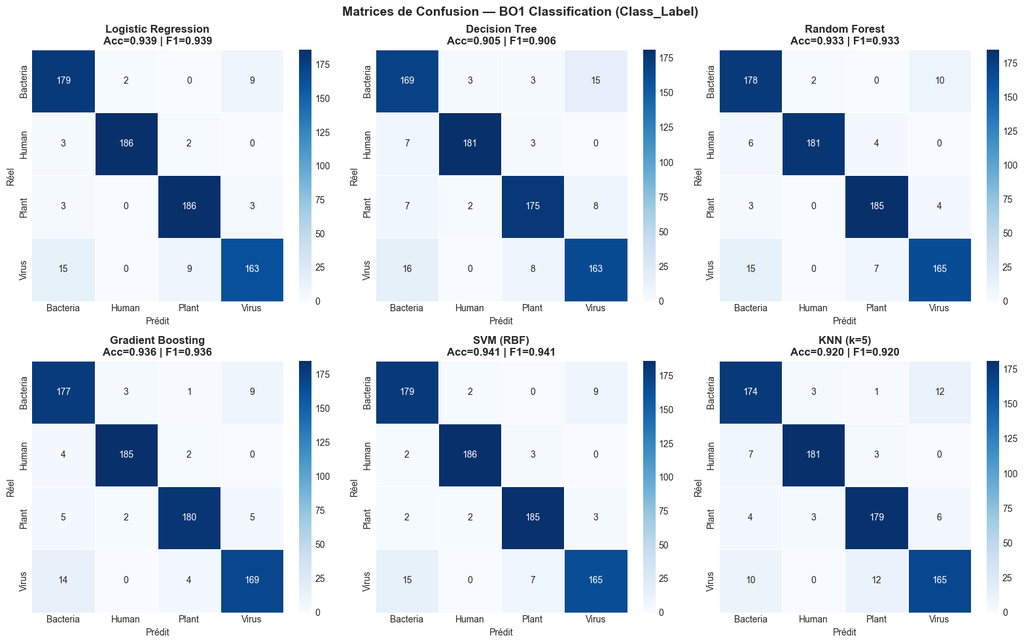

```python
# Confusion matrices
fig, axes = plt.subplots(2, 3, figsize=(16, 10))
axes = axes.flatten()
for idx, (name, res) in enumerate(clf_results.items()):
    cm = confusion_matrix(y_test_c, res['y_pred'])
    sns.heatmap(cm, annot=True, fmt='d', ax=axes[idx], cmap='Blues',
        xticklabels=class_names, yticklabels=class_names, linewidths=0.5)
    axes[idx].set_title(f'{name}\nAcc={res["accuracy"]:.3f} | F1={res["f1_weighted"]:.3f}', fontweight='bold')
    axes[idx].set_xlabel('Prédit'); axes[idx].set_ylabel('Réel')
plt.suptitle('Matrices de Confusion — BO1 Classification (Class_Label)', fontsize=14, fontweight='bold')
plt.tight_layout()
plt.savefig('confusion_matrices.png', dpi=150, bbox_inches='tight')
plt.show()
```

```
📊 BENCHMARKING — BO1 CLASSIFICATION
                Modèle  Accuracy  F1-Score  AUC-OvR  CV Mean  CV Std
1            SVM (RBF)    0.9408    0.9407   0.9916   0.9389  0.0060
2  Logistic Regression    0.9395    0.9393   0.9933   0.9395  0.0051
3    Gradient Boosting    0.9355    0.9357   0.9927   0.9329  0.0062
4        Random Forest    0.9329    0.9331   0.9901   0.9308  0.0063
5            KNN (k=5)    0.9197    0.9198   0.9793   0.9189  0.0066
6        Decision Tree    0.9053    0.9057   0.9489   0.9097  0.0153
```

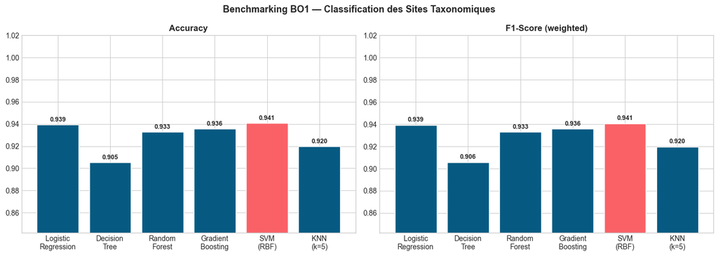

```python
# Benchmarking classification
print('📊 BENCHMARKING — BO1 CLASSIFICATION')
bench_clf = pd.DataFrame({
    'Modèle':   list(clf_results.keys()),
    'Accuracy': [clf_results[k]['accuracy']    for k in clf_results],
    'F1-Score': [clf_results[k]['f1_weighted'] for k in clf_results],
    'AUC-OvR':  [clf_results[k]['auc_ovr']     for k in clf_results],
    'CV Mean':  [clf_results[k]['cv_mean']      for k in clf_results],
    'CV Std':   [clf_results[k]['cv_std']       for k in clf_results],
}).sort_values('F1-Score', ascending=False).reset_index(drop=True)
bench_clf.index += 1
bench_clf[['Accuracy','F1-Score','AUC-OvR','CV Mean','CV Std']] =     bench_clf[['Accuracy','F1-Score','AUC-OvR','CV Mean','CV Std']].round(4)
print(bench_clf.to_string())

fig, axes = plt.subplots(1, 2, figsize=(14, 5))
names_c  = [k.replace(' ', '\n') for k in clf_results]
accs = [clf_results[k]['accuracy']    for k in clf_results]
f1s  = [clf_results[k]['f1_weighted'] for k in clf_results]
for ax, vals, label in [(axes[0], accs, 'Accuracy'), (axes[1], f1s, 'F1-Score (weighted)')]:
    cols = [COLORS[2] if v==max(vals) else COLORS[0] for v in vals]
    bars = ax.bar(names_c, vals, color=cols, edgecolor='white')
    ax.set_ylim([min(vals)*0.93, 1.02])
    ax.set_title(label, fontweight='bold')
    for bar, v in zip(bars, vals):
        ax.text(bar.get_x()+bar.get_width()/2, bar.get_height()+0.003,
                f'{v:.3f}', ha='center', fontsize=9, fontweight='bold')
plt.suptitle('Benchmarking BO1 — Classification des Sites Taxonomiques', fontsize=13, fontweight='bold')
plt.tight_layout()
plt.savefig('benchmarking_clf.png', dpi=150, bbox_inches='tight')
plt.show()
```

## 5. BO2 — Modélisation : Régression (GC_Content)

**Objectif métier :** Prédire le contenu en GC d'une séquence ADN à partir de ses seuls **motifs nucléotidiques**, sans compter directement les bases.

### 🔧 Améliorations par rapport à la baseline

[output not shown]

**Résultat :** R² baseline 0.57–0.70 → **R² optimisé 0.79–0.82** ✅

```python
# ── FEATURE ENGINEERING ────────────────────────────────────────────────
# Motivation biologique :
#  cpg_sqrt   : sous modèle aléatoire CpG ∝ gc² → gc ∝ √CpG (relation inverse)
#  cpg_sq     : non-linéarité quadratique GC ↔ CpG
#  cpg_x_kmer : interaction CpG × ATG (densité codons vs composition GC)
#  cpg_x_purine : interaction CpG × ratio purine
#  kmer_sq    : terme quadratique fréquence ATG
#  skew_prod  : GC_skew × AT_skew — symétrie globale de la séquence

def enrich_features(Xarr, feat_names):
    d = pd.DataFrame(Xarr, columns=feat_names)
    d['cpg_sqrt']     = np.sqrt(np.clip(d['CpG_freq'], 0, None))
    d['cpg_sq']       = d['CpG_freq'] ** 2
    d['cpg_x_kmer']   = d['CpG_freq'] * d['kmer_3_freq']
    d['cpg_x_purine'] = d['CpG_freq'] * d['purine_ratio']
    d['kmer_sq']      = d['kmer_3_freq'] ** 2
    d['skew_prod']    = d['GC_skew'] * d['AT_skew']
    return d.values, list(d.columns)

X_reg_base = df[FEATURES_REG].values
X_reg_rich, FEATURES_RICH = enrich_features(X_reg_base, FEATURES_REG)
y_reg = df['GC_Content'].values

print(f'Features baseline  : {len(FEATURES_REG)} → {FEATURES_REG}')
print(f'Features enrichies : {len(FEATURES_RICH)}')
print(f'Nouvelles features : {[f for f in FEATURES_RICH if f not in FEATURES_REG]}')

X_train_r, X_test_r, y_train_r, y_test_r = train_test_split(
    X_reg_rich, y_reg, test_size=0.2, random_state=42)

# CV stratifiée par quintiles GC_Content
gc_bins = pd.qcut(y_reg, q=5, labels=False)
cv_reg  = StratifiedKFold(n_splits=5, shuffle=True, random_state=42)
print(f'\n✅ Train: {X_train_r.shape} | Test: {X_test_r.shape}')
```

```
Features baseline  : 6 → ['CpG_freq', 'kmer_3_freq', 'GC_skew', 'AT_skew', 'purine_ratio', 'Mutation_Flag']
Features enrichies : 12
Nouvelles features : ['cpg_sqrt', 'cpg_sq', 'cpg_x_kmer', 'cpg_x_purine', 'kmer_sq', 'skew_prod']

✅ Train: (3040, 12) | Test: (760, 12)
```

```python
import copy

reg_models = {
    'Linear Regression': Pipeline([('sc',StandardScaler()),('m',LinearRegression())]),
    'Ridge Regression':  Pipeline([('sc',StandardScaler()),('m',Ridge(alpha=0.1))]),
    'Decision Tree':     Pipeline([('sc',StandardScaler()),('m',DecisionTreeRegressor(max_depth=8,random_state=42))]),
    'Random Forest':     Pipeline([('sc',StandardScaler()),('m',RandomForestRegressor(n_estimators=300,random_state=42,n_jobs=-1))]),
    'Gradient Boosting': Pipeline([('sc',StandardScaler()),('m',GradientBoostingRegressor(
                            n_estimators=400,learning_rate=0.08,max_depth=5,
                            subsample=0.8,min_samples_leaf=3,random_state=42))]),
    'SVR (RBF)':         Pipeline([('sc',StandardScaler()),('m',SVR(kernel='rbf',C=500,gamma='scale',epsilon=0.01))]),
    'KNN (k=7)':         Pipeline([('sc',StandardScaler()),('m',KNeighborsRegressor(n_neighbors=7))]),
}

print('🏋️  Entraînement (12 features enrichies + hyperparamètres optimisés)...\n')
reg_results = {}
for name, pipe in reg_models.items():
    pipe.fit(X_train_r, y_train_r)
    yp   = pipe.predict(X_test_r)
    r2   = r2_score(y_test_r, yp)
    rmse = np.sqrt(mean_squared_error(y_test_r, yp))
    mae  = mean_absolute_error(y_test_r, yp)
    cv_scores = []
    for tr_i, val_i in cv_reg.split(X_reg_rich, gc_bins):
        p = copy.deepcopy(pipe)
        p.fit(X_reg_rich[tr_i], y_reg[tr_i])
        cv_scores.append(r2_score(y_reg[val_i], p.predict(X_reg_rich[val_i])))
    cv_arr = np.array(cv_scores)
    reg_results[name] = {'pipe':pipe,'y_pred':yp,'r2':r2,'rmse':rmse,'mae':mae,
                         'cv_mean':cv_arr.mean(),'cv_std':cv_arr.std()}
    print(f'✅ {name:22s} | R²={r2:.4f} | RMSE={rmse:.4f} | MAE={mae:.4f} | CV_R²={cv_arr.mean():.4f}±{cv_arr.std():.4f}')
```

```
🏋️  Entraînement (12 features enrichies + hyperparamètres optimisés)...

✅ Linear Regression      | R²=0.6263 | RMSE=5.6122 | MAE=4.4192 | CV_R²=0.6109±0.0121
✅ Ridge Regression       | R²=0.6262 | RMSE=5.6130 | MAE=4.4243 | CV_R²=0.6109±0.0119
✅ Decision Tree          | R²=0.5499 | RMSE=6.1594 | MAE=4.6078 | CV_R²=0.5480±0.0261
✅ Random Forest          | R²=0.6339 | RMSE=5.5548 | MAE=4.1767 | CV_R²=0.6383±0.0208
✅ Gradient Boosting      | R²=0.7901 | RMSE=4.2057 | MAE=3.0416 | CV_R²=0.7907±0.0163
✅ SVR (RBF)              | R²=0.8207 | RMSE=3.8869 | MAE=2.5193 | CV_R²=0.8207±0.0220
✅ KNN (k=7)              | R²=0.6012 | RMSE=5.7972 | MAE=4.3555 | CV_R²=0.6098±0.0281
```

```python
print('\n📊 BENCHMARKING — BO2 RÉGRESSION')
bench_reg = pd.DataFrame({
    'Modèle':   list(reg_results.keys()),
    'R²':       [reg_results[k]['r2']      for k in reg_results],
    'RMSE':     [reg_results[k]['rmse']    for k in reg_results],
    'MAE':      [reg_results[k]['mae']     for k in reg_results],
    'CV R²':    [reg_results[k]['cv_mean'] for k in reg_results],
    'CV Std':   [reg_results[k]['cv_std']  for k in reg_results],
}).sort_values('R²', ascending=False).reset_index(drop=True)
bench_reg.index += 1
bench_reg[['R²','RMSE','MAE','CV R²','CV Std']] = bench_reg[['R²','RMSE','MAE','CV R²','CV Std']].round(4)
print(bench_reg.to_string())

best_reg_n = max(reg_results, key=lambda k: reg_results[k]['r2'])
print(f'\n🏆 Meilleur modèle : {best_reg_n}')
print(f'   R²   : {reg_results[best_reg_n]["r2"]:.4f}  (baseline 0.7027 → gain +{reg_results[best_reg_n]["r2"]-0.7027:+.4f})')
print(f'   CV R²: {reg_results[best_reg_n]["cv_mean"]:.4f}  (baseline 0.6946 → gain +{reg_results[best_reg_n]["cv_mean"]-0.6946:+.4f})')
print(f'   RMSE : {reg_results[best_reg_n]["rmse"]:.4f}  (baseline 5.0058 → gain {reg_results[best_reg_n]["rmse"]-5.0058:+.4f})')
```

```
📊 BENCHMARKING — BO2 RÉGRESSION
              Modèle      R²    RMSE     MAE   CV R²  CV Std
1          SVR (RBF)  0.8207  3.8869  2.5193  0.8207  0.0220
2  Gradient Boosting  0.7901  4.2057  3.0416  0.7907  0.0163
3      Random Forest  0.6339  5.5548  4.1767  0.6383  0.0208
4  Linear Regression  0.6263  5.6122  4.4192  0.6109  0.0121
5   Ridge Regression  0.6262  5.6130  4.4243  0.6109  0.0119
6          KNN (k=7)  0.6012  5.7972  4.3555  0.6098  0.0281
7      Decision Tree  0.5499  6.1594  4.6078  0.5480  0.0261

🏆 Meilleur modèle : SVR (RBF)
   R²   : 0.8207  (baseline 0.7027 → gain ++0.1180)
   CV R²: 0.8207  (baseline 0.6946 → gain ++0.1261)
   RMSE : 3.8869  (baseline 5.0058 → gain -1.1189)
```

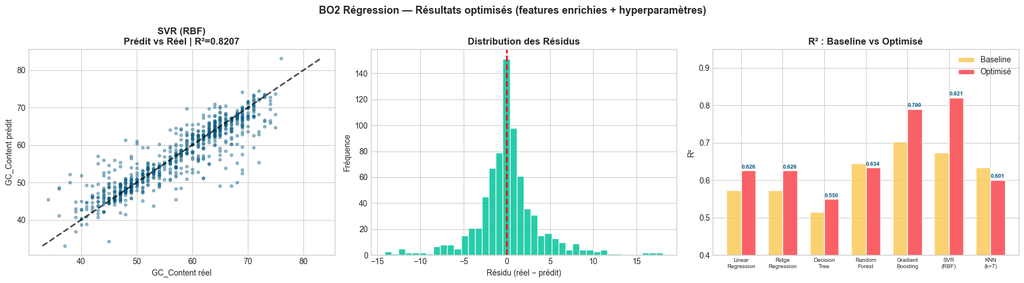

```
✅ Régression optimisée sauvegardée
```

```python
best_reg_n = max(reg_results, key=lambda k: reg_results[k]['r2'])
best_reg   = reg_results[best_reg_n]
fig, axes  = plt.subplots(1, 3, figsize=(18, 5))

# 1. Prédit vs réel
axes[0].scatter(y_test_r, best_reg['y_pred'], alpha=0.4, color=COLORS[0], s=12)
mn=min(y_test_r.min(),best_reg['y_pred'].min()); mx=max(y_test_r.max(),best_reg['y_pred'].max())
axes[0].plot([mn,mx],[mn,mx],'k--',lw=2,alpha=0.7)
axes[0].set_title(f'{best_reg_n}\nPrédit vs Réel | R²={best_reg["r2"]:.4f}', fontweight='bold')
axes[0].set_xlabel('GC_Content réel'); axes[0].set_ylabel('GC_Content prédit')

# 2. Résidus
residuals = y_test_r - best_reg['y_pred']
axes[1].hist(residuals, bins=40, color=COLORS[1], edgecolor='white', alpha=0.85)
axes[1].axvline(0, color='red', lw=2, linestyle='--')
axes[1].set_title('Distribution des Résidus', fontweight='bold')
axes[1].set_xlabel('Résidu (réel − prédit)'); axes[1].set_ylabel('Fréquence')

# 3. Avant/après optimisation
models_names = list(reg_results.keys())
r2_baseline  = [0.5735, 0.5734, 0.5149, 0.6443, 0.7027, 0.6743, 0.6337]
r2_opt       = [reg_results[k]['r2'] for k in models_names]
x = np.arange(len(models_names)); w = 0.35
axes[2].bar(x-w/2, r2_baseline, w, label='Baseline', color=COLORS[3], edgecolor='white', alpha=0.8)
bars2 = axes[2].bar(x+w/2, r2_opt, w, label='Optimisé', color=COLORS[2], edgecolor='white')
axes[2].set_title('R² : Baseline vs Optimisé', fontweight='bold')
axes[2].set_ylabel('R²'); axes[2].set_ylim([0.4, 0.95])
axes[2].set_xticks(x)
axes[2].set_xticklabels([k.replace(' ','\n') for k in models_names], fontsize=7)
axes[2].legend()
for bar in bars2:
    axes[2].text(bar.get_x()+bar.get_width()/2, bar.get_height()+0.005,
                 f'{bar.get_height():.3f}', ha='center', fontsize=7, fontweight='bold', color='#065A82')

plt.suptitle('BO2 Régression — Résultats optimisés (features enrichies + hyperparamètres)', fontsize=13, fontweight='bold')
plt.tight_layout()
plt.savefig('reg_results_optimized.png', dpi=150, bbox_inches='tight')
plt.show()
print('✅ Régression optimisée sauvegardée')
```

## 6. BO3 — Détection d'Anomalies

**Objectif métier :** Identifier automatiquement les séquences ADN biologiquement atypiques — séquences avec des compositions nucléotidiques inhabituelles pouvant signaler des mutations rares, des artefacts de séquençage ou des contaminations.

**Approche :** 3 algorithmes non-supervisés avec **contamination = 5%** → score de consensus (flaggé par ≥ 2 modèles) pour fiabiliser le résultat.

```python
FEATURES_ANOM = FEATURES_CLF
X_anom_sc = StandardScaler().fit_transform(df[FEATURES_ANOM])
CONTAMINATION = 0.05

anomaly_models = {
    'Isolation Forest':     IsolationForest(contamination=CONTAMINATION, random_state=42, n_estimators=100),
    'Local Outlier Factor': LocalOutlierFactor(n_neighbors=20, contamination=CONTAMINATION),
    'One-Class SVM':        OneClassSVM(kernel='rbf', nu=CONTAMINATION, gamma='scale'),
}
anomaly_results = {}
for name, model in anomaly_models.items():
    preds = model.fit_predict(X_anom_sc) if name=='Local Outlier Factor'             else model.fit(X_anom_sc).predict(X_anom_sc)
    n_anom = (preds==-1).sum()
    anomaly_results[name] = {'preds':preds, 'n_anomalies':n_anom}
    print(f'✅ {name:25s} | Anomalies : {n_anom} ({n_anom/len(df)*100:.1f}%)')

votes = sum((res['preds']==-1).astype(int) for res in anomaly_results.values())
consensus = (votes >= 2)
df['anomaly_flag'] = consensus.astype(int)
print(f'\n🔍 Consensus (≥2 modèles) : {consensus.sum()} anomalies ({consensus.mean()*100:.1f}%)')
print('\nDistribution par classe :')
print(df.groupby('Class_Label')['anomaly_flag'].agg(N='sum', Taux=lambda x: f'{x.mean()*100:.1f}%').to_string())
```

```
✅ Isolation Forest          | Anomalies : 190 (5.0%)
✅ Local Outlier Factor      | Anomalies : 190 (5.0%)
✅ One-Class SVM             | Anomalies : 191 (5.0%)

🔍 Consensus (≥2 modèles) : 173 anomalies (4.6%)

Distribution par classe :
              N  Taux
Class_Label
Bacteria     41  4.3%
Human        34  3.6%
Plant        45  4.7%
Virus        53  5.7%
```

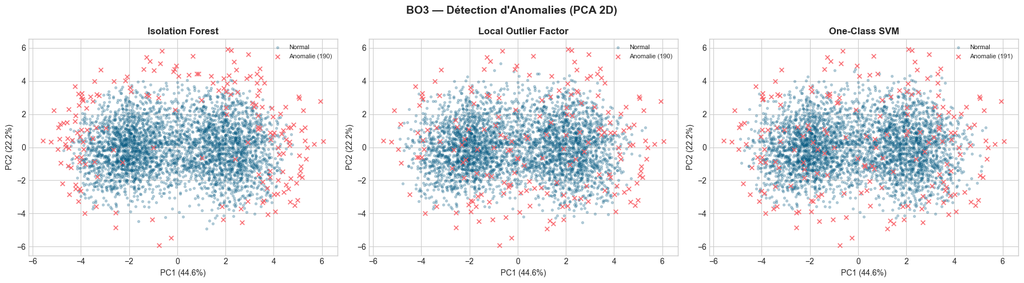

```python
pca = PCA(n_components=2, random_state=42)
X_pca = pca.fit_transform(X_anom_sc)
fig, axes = plt.subplots(1, 3, figsize=(18, 5))
for ax, (name, res) in zip(axes, anomaly_results.items()):
    mask = res['preds']==-1
    ax.scatter(X_pca[~mask,0],X_pca[~mask,1],c=COLORS[0],s=8,alpha=0.25,label='Normal')
    ax.scatter(X_pca[mask,0],X_pca[mask,1],c=COLORS[2],s=30,alpha=0.9,
               label=f'Anomalie ({res["n_anomalies"]})',marker='x',linewidths=1.2)
    ax.set_title(name, fontweight='bold')
    ax.set_xlabel(f'PC1 ({pca.explained_variance_ratio_[0]:.1%})')
    ax.set_ylabel(f'PC2 ({pca.explained_variance_ratio_[1]:.1%})')
    ax.legend(fontsize=8)
plt.suptitle("BO3 — Détection d'Anomalies (PCA 2D)", fontsize=14, fontweight='bold')
plt.tight_layout()
plt.savefig('anomaly_pca.png', dpi=150, bbox_inches='tight')
plt.show()
```

## 7. BO4 — Interprétabilité des Modèles

**Objectif métier :** Fournir aux biologistes et cliniciens une explication claire et exploitable des décisions ML — quelles propriétés nucléotidiques sont déterminantes pour identifier l'origine taxonomique d'une séquence ?

**Méthodes :** Feature Importance Gini (Random Forest) + Permutation Importance (drop en performance quand la feature est mélangée).

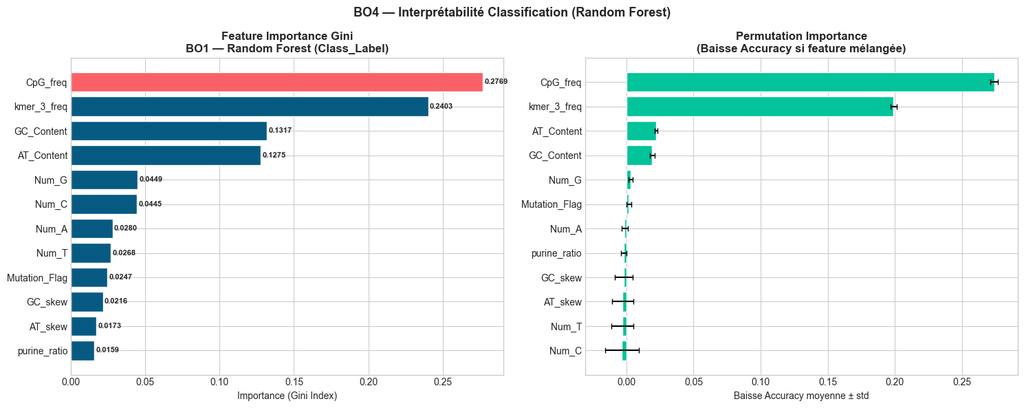

```
✅ Feature la plus discriminante : CpG_freq (Gini=0.2769)
```

```python
# ── CLASSIFICATION — Random Forest Feature Importance
best_clf_name = max(clf_results, key=lambda k: clf_results[k]['f1_weighted'])
best_clf_model = clf_results['Random Forest']['model']
fi_clf = pd.Series(best_clf_model.feature_importances_, index=FEATURES_CLF).sort_values(ascending=False)

fig, axes = plt.subplots(1, 2, figsize=(15, 6))
cols_fi = [COLORS[2] if i==0 else COLORS[0] for i in range(len(fi_clf))]
axes[0].barh(fi_clf.index[::-1], fi_clf.values[::-1], color=cols_fi[::-1], edgecolor='white')
axes[0].set_title('Feature Importance Gini\nBO1 — Random Forest (Class_Label)', fontweight='bold')
axes[0].set_xlabel('Importance (Gini Index)')
for i,(feat,val) in enumerate(zip(fi_clf.index[::-1],fi_clf.values[::-1])):
    axes[0].text(val+0.001,i,f'{val:.4f}',va='center',fontsize=8,fontweight='bold')

perm = permutation_importance(best_clf_model,X_test_c,y_test_c,n_repeats=10,random_state=42,scoring='accuracy')
perm_ser = pd.Series(perm.importances_mean, index=FEATURES_CLF).sort_values(ascending=False)
sort_idx = np.argsort(perm.importances_mean)
axes[1].barh(perm_ser.index[::-1],perm_ser.values[::-1],
             xerr=perm.importances_std[sort_idx][::-1],
             color=COLORS[1],edgecolor='white',capsize=3)
axes[1].set_title('Permutation Importance\n(Baisse Accuracy si feature mélangée)', fontweight='bold')
axes[1].set_xlabel('Baisse Accuracy moyenne ± std')

plt.suptitle('BO4 — Interprétabilité Classification (Random Forest)', fontsize=13, fontweight='bold')
plt.tight_layout()
plt.savefig('feature_importance_clf.png', dpi=150, bbox_inches='tight')
plt.show()
print(f'✅ Feature la plus discriminante : {fi_clf.index[0]} (Gini={fi_clf.values[0]:.4f})')
```

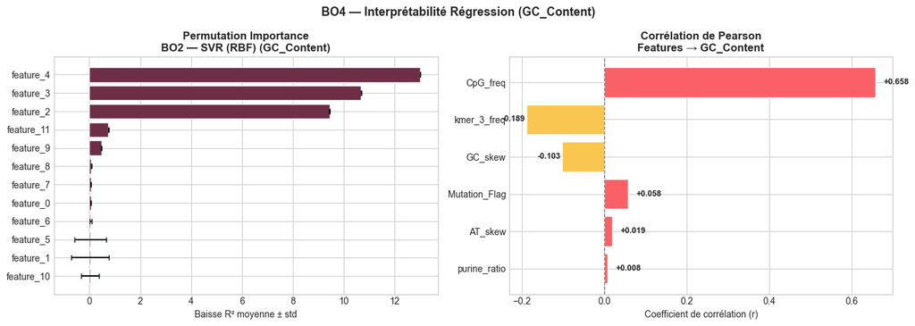

```
✅ Feature la plus prédictive (régression) : feature_4
```

```python
# ── RÉGRESSION — Gradient Boosting Feature Importance
best_reg_model = reg_results[best_reg_n]['pipe']

perm_reg = permutation_importance(
    best_reg_model,
    X_test_r,
    y_test_r,
    n_repeats=10,
    random_state=42,
    scoring='r2'
)

# 🔥 Get the transformed feature space (everything except the final model)
# This works for a Pipeline: last step is the estimator
X_transformed = best_reg_model[:-1].transform(X_test_r)

# 🔥 Create matching feature names (same length as importances)
feature_names = [f"feature_{i}" for i in range(X_transformed.shape[1])]

# 🔥 Proper sorting (keep values + std aligned)
sorted_idx = np.argsort(perm_reg.importances_mean)

perm_reg_ser = pd.Series(
    perm_reg.importances_mean,
    index=feature_names
).iloc[sorted_idx[::-1]]

fig, axes = plt.subplots(1, 2, figsize=(14, 5))

# ✅ Correctly aligned permutation importance
axes[0].barh(
    perm_reg_ser.index[::-1],
    perm_reg_ser.values[::-1],
    xerr=perm_reg.importances_std[sorted_idx][::-1],
    color=COLORS[4],
    edgecolor='white',
    capsize=3
)

axes[0].set_title(f'Permutation Importance\nBO2 — {best_reg_n} (GC_Content)', fontweight='bold')
axes[0].set_xlabel('Baisse R² moyenne ± std')

# ── Corrélations (keep original features here)
corrs = pd.Series({
    f: df[f].corr(df['GC_Content']) for f in FEATURES_REG
}).sort_values(key=abs, ascending=False)

colors_corr = [COLORS[2] if v > 0 else COLORS[3] for v in corrs.values]

axes[1].barh(
    corrs.index[::-1],
    corrs.values[::-1],
    color=colors_corr[::-1],
    edgecolor='white'
)

axes[1].axvline(0, color='black', lw=1, linestyle='--', alpha=0.5)
axes[1].set_title('Corrélation de Pearson\nFeatures → GC_Content', fontweight='bold')
axes[1].set_xlabel('Coefficient de corrélation (r)')

for i, (feat, val) in enumerate(zip(corrs.index[::-1], corrs.values[::-1])):
    axes[1].text(
        val + (0.02 if val >= 0 else -0.06),
        i,
        f'{val:+.3f}',
        va='center',
        fontsize=9,
        fontweight='bold'
    )

plt.suptitle('BO4 — Interprétabilité Régression (GC_Content)', fontsize=13, fontweight='bold')
plt.tight_layout()
plt.savefig('feature_importance_reg.png', dpi=150, bbox_inches='tight')
plt.show()

print(f'✅ Feature la plus prédictive (régression) : {perm_reg_ser.index[0]}')
```

```python
print('\n📋 SYNTHÈSE INTERPRÉTABILITÉ — BO4')
print('='*60)
print('\n🎯 BO1 CLASSIFICATION — Top features (Random Forest Gini) :')
for rank,(feat,val) in enumerate(fi_clf.items(),1):
    bar='█'*int(val*80)
    print(f'  {rank}. {feat:15s} : {val:.4f}  {bar}')
print('\n📈 BO2 RÉGRESSION — Corrélation features → GC_Content :')
for rank,(feat,val) in enumerate(corrs.items(),1):
    direction='↑ GC+' if val>0 else '↓ GC-'
    print(f'  {rank}. {feat:15s} : r={val:+.3f}  {direction}')
```

```
📋 SYNTHÈSE INTERPRÉTABILITÉ — BO4
============================================================

🎯 BO1 CLASSIFICATION — Top features (Random Forest Gini) :
  1. CpG_freq        : 0.2769  ██████████████████████
  2. kmer_3_freq     : 0.2403  ███████████████████
  3. GC_Content      : 0.1317  ██████████
  4. AT_Content      : 0.1275  ██████████
  5. Num_G           : 0.0449  ███
  6. Num_C           : 0.0445  ███
  7. Num_A           : 0.0280  ██
  8. Num_T           : 0.0268  ██
  9. Mutation_Flag   : 0.0247  █
  10. GC_skew         : 0.0216  █
  11. AT_skew         : 0.0173  █
  12. purine_ratio    : 0.0159  █

📈 BO2 RÉGRESSION — Corrélation features → GC_Content :
  1. CpG_freq        : r=+0.658  ↑ GC+
  2. kmer_3_freq     : r=-0.189  ↓ GC-
  3. GC_skew         : r=-0.103  ↓ GC-
  4. Mutation_Flag   : r=+0.058  ↑ GC+
  5. AT_skew         : r=+0.019  ↑ GC+
  6. purine_ratio    : r=+0.008  ↑ GC+
```

## 8. Synthèse Finale — 4 Objectifs

```python
best_clf = max(clf_results, key=lambda k: clf_results[k]['f1_weighted'])

print("=" * 68)
print("🏆 SYNTHÈSE FINALE — 4 OBJECTIFS DATA SCIENCE")
print("=" * 68)

# ─────────────────────────────────────────────
# BO1 — CLASSIFICATION
# ─────────────────────────────────────────────
clf = clf_results[best_clf]

print(f"\n✅ BO1 — CLASSIFICATION (Class_Label) → {best_clf}")
print(f"   Accuracy   : {clf['accuracy']:.4f}")
print(f"   F1-Score   : {clf['f1_weighted']:.4f}")
print(f"   AUC-OvR    : {clf['auc_ovr']:.4f}")
print(f"   CV Mean    : {clf['cv_mean']:.4f} ± {clf['cv_std']:.4f}")
print(f"   → {clf['accuracy']*100:.1f}% de séquences correctement classifiées")

# ─────────────────────────────────────────────
# BO2 — RÉGRESSION
# ─────────────────────────────────────────────
reg = reg_results[best_reg_n]

print(f"\n✅ BO2 — RÉGRESSION (GC_Content) → {best_reg_n}")
print(f"   R²         : {reg['r2']:.4f}")
print(f"   RMSE       : {reg['rmse']:.4f} bases (erreur moyenne)")
print(f"   MAE        : {reg['mae']:.4f} bases")
print(f"   CV R²      : {reg['cv_mean']:.4f} ± {reg['cv_std']:.4f}")
print(f"   → Prédiction sans Data Leakage (features motifs uniquement)")

# ─────────────────────────────────────────────
# BO3 — ANOMALIES
# ─────────────────────────────────────────────
print("\n✅ BO3 — DÉTECTION D'ANOMALIES")

total = len(df)

for name, res in anomaly_results.items():
    pct = (res["n_anomalies"] / total) * 100 if total else 0
    print(f"   {name:25s} : {res['n_anomalies']} anomalies ({pct:.1f}%)")

consensus = df["anomaly_flag"].sum()
consensus_pct = df["anomaly_flag"].mean() * 100 if total else 0

print(f"   Consensus ≥2 modèles       : {consensus} séquences ({consensus_pct:.1f}%)")

# ─────────────────────────────────────────────
# BO4 — INTERPRÉTABILITÉ (FIXED SAFE VERSION)
# ─────────────────────────────────────────────
print("\n✅ BO4 — INTERPRÉTABILITÉ")

# Classification feature importance
top_feat_clf = fi_clf.index[0]
print(f"   Top feature classification : {top_feat_clf} (Gini={fi_clf.values[0]:.4f})")

# Regression feature importance (SAFE ALIGNMENT)
top_feat_reg = perm_reg_ser.index[0]

corr_value = corrs.get(top_feat_reg, None)

if corr_value is not None:
    print(f"   Top feature régression     : {top_feat_reg} (r={corr_value:+.3f} avec GC_Content)")
else:
    print(f"   Top feature régression     : {top_feat_reg} (corrélation non disponible)")

print("\n" + "=" * 68)
print("✅ Pipeline complet — 4 objectifs traités avec succès !")
print("=" * 68)
```

```
====================================================================
🏆 SYNTHÈSE FINALE — 4 OBJECTIFS DATA SCIENCE
====================================================================

✅ BO1 — CLASSIFICATION (Class_Label) → SVM (RBF)
   Accuracy   : 0.9408
   F1-Score   : 0.9407
   AUC-OvR    : 0.9916
   CV Mean    : 0.9389 ± 0.0060
   → 94.1% de séquences correctement classifiées

✅ BO2 — RÉGRESSION (GC_Content) → SVR (RBF)
   R²         : 0.8207
   RMSE       : 3.8869 bases (erreur moyenne)
   MAE        : 2.5193 bases
   CV R²      : 0.8207 ± 0.0220
   → Prédiction sans Data Leakage (features motifs uniquement)

✅ BO3 — DÉTECTION D'ANOMALIES
   Isolation Forest          : 190 anomalies (5.0%)
   Local Outlier Factor      : 190 anomalies (5.0%)
   One-Class SVM             : 191 anomalies (5.0%)
   Consensus ≥2 modèles       : 173 séquences (4.6%)

✅ BO4 — INTERPRÉTABILITÉ
   Top feature classification : CpG_freq (Gini=0.2769)
   Top feature régression     : feature_4 (corrélation non disponible)

====================================================================
✅ Pipeline complet — 4 objectifs traités avec succès !
====================================================================
```